# CATAPULTING INTO EXPERIMENTAL DESIGN

DATA299 Statistical Engineering - FA24 - Project 1

Group 6: Graham Blechshmidt, Brooke Proctor, Serenna Walter

# Introduction

  Slings, bows, and rocks–what do these things all have in common? They are predecessors of the catapult. A catapult is a ballistic instrument that works to hurl objects through the air. How did these magnificent works come to be? Greeks and Romans were some of the first to utilize the catapult, though India and the Middle East were also a part of this early usage. These preliminary models were difficult to load, due to the clunky size and lack of uniformity. The Middle Ages brought about great advancements to the catapult, as their role in war became notable. Since then, the mechanisms have been more or less the same across time thus far.

  Luckily, the mechanisms that catapults employ are easy to understand. A catapult is made up of an arm, a string, and a frame, in the most basic of designs. By tightening the string via twisting in one direction, tension builds until it is released, and the arm swings and launches the projectile forward as the arm hits the frame.

  The trajectory of a catapult launch is determined by a few primary factors: the catapult arm, tension, and release angle. The catapult arm is important in this process because the distance traveled will rely heavily on the length of the arm. Tension is also important because that tension is the elastic potential energy that will propel the projectile. Finally, the angle is important, because similar to the twists, the smaller the angle is, the more tension is being built up in order to transfer the potential energy to the projectile. All of these factors implicate the trajectory of the projectile.

  This study seeks to understand the optimal settings of which should be employed during the launching of the catapult in order to achieve the most in-air distance by the projectile. By testing three factors and three levels each, then running some statistical analysis, the study will be able to identify the optimal levels of each factor.

# Methodology

  Starting with catapult arm length, the specific levels used were chosen based on the compatibility with the catapult. The 6-inch arm length was the base length of the base-built catapult. As for the 9-inch arm length, any lengths exceeding this had begun negatively impacting the functionality of the catapult launch itself. The 7.5-inch arm was found to have a center value equidistant from the maximum and minimum lengths. Similarly, the launch angle values were selected to keep the catapult functional. The angles were measured from the ground to the top of the catapult arm. Lower angles meant a shorter arc between the arm and the floor. Angles exceeding 45 degrees were vulnerable to the payload falling off the catapult prematurely, and values too close to 0 would result in a misfire of the catapult. Thus, the angles were chosen as cascading values between both of those thresholds. Lastly, the twist or tension levels were determined based on the maximum strain the rope of the catapult could hold. It was found that 6 two-handed 180-degree twists was the max. The remaining levels were chosen by reducing the max by one or two twists to preserve high tension in the string, allowing successful launches.

  To run the experiment consistently and mitigate needless errors, any alterations to the catapult were kept under control. Namely, when the payload was launched, the catapult launcher (cl1, or cl2) also acted as a stabilizer. The stabilization would occur by holding the catapult down, keeping it parallel to the ground, and firmly in its initial position. When in use, only one individual would be in contact with the catapult at a time. All alterations made to the catapult’s string tension (twists) would remain consistent throughout the experiment by only allowing the designated measurer (an individual not cl1 or cl2) to change it. The length of the catapult arm was solely changed by the designated measurer. Any habits the measurer had then would remain as yet another unchanged variable. The distance the payload traveled was always measured as the distance between the impact spot of the payload on the floor and the closest side of the catapult base. The same tape measure and payload (ping pong ball) were used for the experiment. Therefore, any deformities present on either would remain an unchanged variable. Since the payload was a ping-pong ball, it was more susceptible to air currents. To reduce this acknowledgeable impact the experiment was conducted in a contained environment.

  Uncontrollable variables are present in every experiment. The most prevalent in this experiment was the rapid degradation of the catapult. The catapult experienced the largest decline in functionality in the latter half of the experiment. There were acknowledgments of the deterioration of the catapult. The other most significant uncontrollable variable was the difference in thickness of the catapult arm extender and the base catapult arm. This discrepancy was noted, but that was the limit of any action that could be taken. Ultimately, any attempt to reduce or fix the issue would undermine the validity of the experiment as sources of error would have been intentionally brought about. Knowing this, attempts were made to reduce variables that could be consistent throughout the experiment.

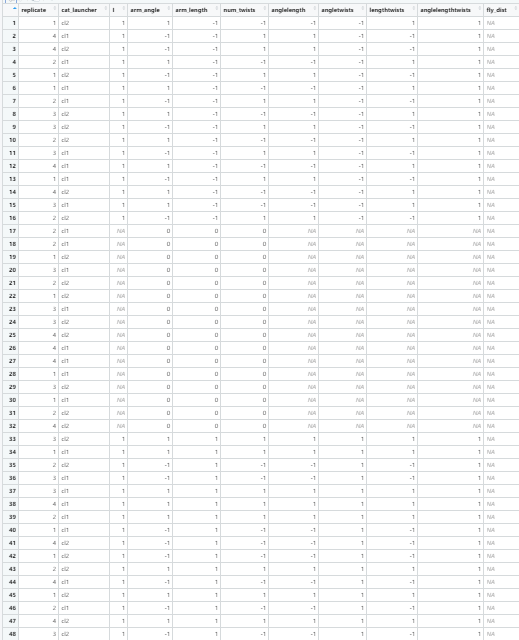